# Project Python Foundations: FoodHub Data Analysis

### Context

The number of restaurants in New York is increasing day by day. Lots of students and busy professionals rely on those restaurants due to their hectic lifestyles. Online food delivery service is a great option for them. It provides them with good food from their favorite restaurants. A food aggregator company FoodHub offers access to multiple restaurants through a single smartphone app.

The app allows the restaurants to receive a direct online order from a customer. The app assigns a delivery person from the company to pick up the order after it is confirmed by the restaurant. The delivery person then uses the map to reach the restaurant and waits for the food package. Once the food package is handed over to the delivery person, he/she confirms the pick-up in the app and travels to the customer's location to deliver the food. The delivery person confirms the drop-off in the app after delivering the food package to the customer. The customer can rate the order in the app. The food aggregator earns money by collecting a fixed margin of the delivery order from the restaurants.

### Objective

The food aggregator company has stored the data of the different orders made by the registered customers in their online portal. They want to analyze the data to get a fair idea about the demand of different restaurants which will help them in enhancing their customer experience. Suppose you are hired as a Data Scientist in this company and the Data Science team has shared some of the key questions that need to be answered. Perform the data analysis to find answers to these questions that will help the company to improve the business.

### Data Description

The data contains the different data related to a food order. The detailed data dictionary is given below.

### Data Dictionary

- order_id: Unique ID of the order
- customer_id: ID of the customer who ordered the food
- restaurant_name: Name of the restaurant
- cuisine_type: Cuisine ordered by the customer
- cost_of_the_order: Cost of the order
- day_of_the_week: Indicates whether the order is placed on a weekday or weekend (The weekday is from Monday to Friday and the weekend is Saturday and Sunday)
- rating: Rating given by the customer out of 5
- food_preparation_time: Time (in minutes) taken by the restaurant to prepare the food. This is calculated by taking the difference between the timestamps of the restaurant's order confirmation and the delivery person's pick-up confirmation.
- delivery_time: Time (in minutes) taken by the delivery person to deliver the food package. This is calculated by taking the difference between the timestamps of the delivery person's pick-up confirmation and drop-off information

### Let us start by importing the required libraries

```python
'''
# Installing the libraries with the specified version when running local.
!pip install numpy==1.25.2 pandas==1.5.3 matplotlib==3.7.1 seaborn==0.13.1 -q --user
'''
```

```
'\n# Installing the libraries with the specified version when running local.\n!pip install numpy==1.25.2 pandas==1.5.3 matplotlib==3.7.1 seaborn==0.13.1 -q --user\n'
```

**Note**: *After running the above cell, kindly restart the notebook kernel and run all cells sequentially from the start again.*

```python
# import libraries for data manipulation
import numpy as np
import pandas as pd

# import libraries for data visualization
import matplotlib.pyplot as plt
from matplotlib.ticker import MultipleLocator
import seaborn as sns

# define initial configs
sns.set_theme(style="darkgrid")
```

### Understanding the structure of the data

```python
# Access rights for Google Colab
from google.colab import drive
drive.mount('/content/drive')
```

```python
#read the data
data = pd.read_csv('/content/drive/MyDrive/Colab_Notebooks/20240422_PythonFoundations/Project1/foodhub_order.csv')
```

```python
#view the first 5 rows
data.head()
```

|  | order_id | customer_id | restaurant_name | cuisine_type | cost_of_the_order | day_of_the_week | rating | food_preparation_time | delivery_time |
| --- | --- | --- | --- | --- | --- | --- | --- | --- | --- |
| 0 | 1477147 | 337525 | Hangawi | Korean | 30.75 | Weekend | Not given | 25 | 20 |
| 1 | 1477685 | 358141 | Blue Ribbon Sushi Izakaya | Japanese | 12.08 | Weekend | Not given | 25 | 23 |
| 2 | 1477070 | 66393 | Cafe Habana | Mexican | 12.23 | Weekday | 5 | 23 | 28 |
| 3 | 1477334 | 106968 | Blue Ribbon Fried Chicken | American | 29.20 | Weekend | 3 | 25 | 15 |
| 4 | 1478249 | 76942 | Dirty Bird to Go | American | 11.59 | Weekday | 4 | 25 | 24 |

### **Question 1:** How many rows and columns are present in the data? [0.5 mark]

```python
#check how many rows and columns are present
print('There are', len(data), 'rows &', len(data.columns),'columns')
```

```
There are 1898 rows & 9 columns
```

#### Observations:

There are 1898 rows & 9 columns

### **Question 2:** What are the datatypes of the different columns in the dataset? (The info() function can be used) [0.5 mark]

```python
data.info()
```

```
<class 'pandas.core.frame.DataFrame'>
RangeIndex: 1898 entries, 0 to 1897
Data columns (total 9 columns):
 #   Column                 Non-Null Count  Dtype
---  ------                 --------------  -----
 0   order_id               1898 non-null   int64
 1   customer_id            1898 non-null   int64
 2   restaurant_name        1898 non-null   object
 3   cuisine_type           1898 non-null   object
 4   cost_of_the_order      1898 non-null   float64
 5   day_of_the_week        1898 non-null   object
 6   rating                 1898 non-null   object
 7   food_preparation_time  1898 non-null   int64
 8   delivery_time          1898 non-null   int64
dtypes: float64(1), int64(4), object(4)
memory usage: 133.6+ KB
```

#### Observations:

- There are 5 numerical columns and 4 object type columns.
- "rating" column is being read as object type but it should be a numerical column float64.

### **Question 3:** Are there any missing values in the data? If yes, treat them using an appropriate method. [1 mark] - done

```python
# check if there are null/blank cells
data.isnull().sum()
```

```
order_id                 0
customer_id              0
restaurant_name          0
cuisine_type             0
cost_of_the_order        0
day_of_the_week          0
rating                   0
food_preparation_time    0
delivery_time            0
dtype: int64
```

```python
data.duplicated().sum()
```

```
0
```

```python
# check why rating column has object type
data['rating'].unique()
```

```
array(['Not given', '5', '3', '4'], dtype=object)
```

#### Observations:

```python
#duplicate rating with a new name
data['ratingNum'] = data['rating']

#move column to the side of rating
moveColumn = data.pop('ratingNum')
data.insert(7, 'ratingNum', moveColumn)

# replace values with nan
data['ratingNum'] = data['ratingNum'].replace(['Not given'],np.nan)

# changing the data type to float for so rating is more excatly based on most reviews systems
data['ratingNum'] = data['ratingNum'].astype(float)

# check if both lines above did the change
data['ratingNum'].unique()
```

```
array([nan,  5.,  3.,  4.])
```

```python
data.isnull().sum()
```

```
order_id                   0
customer_id                0
restaurant_name            0
cuisine_type               0
cost_of_the_order          0
day_of_the_week            0
rating                     0
ratingNum                736
food_preparation_time      0
delivery_time              0
dtype: int64
```

```python
data.info()
```

```
<class 'pandas.core.frame.DataFrame'>
RangeIndex: 1898 entries, 0 to 1897
Data columns (total 10 columns):
 #   Column                 Non-Null Count  Dtype
---  ------                 --------------  -----
 0   order_id               1898 non-null   int64
 1   customer_id            1898 non-null   int64
 2   restaurant_name        1898 non-null   object
 3   cuisine_type           1898 non-null   object
 4   cost_of_the_order      1898 non-null   float64
 5   day_of_the_week        1898 non-null   object
 6   rating                 1898 non-null   object
 7   ratingNum              1162 non-null   float64
 8   food_preparation_time  1898 non-null   int64
 9   delivery_time          1898 non-null   int64
dtypes: float64(2), int64(4), object(4)
memory usage: 148.4+ KB
```

#### Observations:

- We observe the new column 'ratingNum' as numerical
- No imputation has been done as the missing 'rating' entries are almost half of the data. A new column will be created in order to impute the mean of the ratings and compare between both columns.

```python
#duplicate 'ratingNum' with a new name 'ratingImput'
data['ratingImput'] = data['ratingNum']

#move column to the side of 'ratingNum'
moveColumn = data.pop('ratingImput')
data.insert(8, 'ratingImput', moveColumn)

# imputing missing values in 'ratingImput' column
data['ratingImput'] = data['ratingNum'].fillna(value=data.groupby(['restaurant_name'])['ratingNum'].transform('mean'))

data.head()
```

|  | order_id | customer_id | restaurant_name | cuisine_type | cost_of_the_order | day_of_the_week | rating | ratingNum | ratingImput | food_preparation_time | delivery_time |
| --- | --- | --- | --- | --- | --- | --- | --- | --- | --- | --- | --- |
| 0 | 1477147 | 337525 | Hangawi | Korean | 30.75 | Weekend | Not given | NaN | NaN | 25 | 20 |
| 1 | 1477685 | 358141 | Blue Ribbon Sushi Izakaya | Japanese | 12.08 | Weekend | Not given | NaN | 4.333333 | 25 | 23 |
| 2 | 1477070 | 66393 | Cafe Habana | Mexican | 12.23 | Weekday | 5 | 5.0 | 5.000000 | 23 | 28 |
| 3 | 1477334 | 106968 | Blue Ribbon Fried Chicken | American | 29.20 | Weekend | 3 | 3.0 | 3.000000 | 25 | 15 |
| 4 | 1478249 | 76942 | Dirty Bird to Go | American | 11.59 | Weekday | 4 | 4.0 | 4.000000 | 25 | 24 |

```python
data.groupby(['restaurant_name']).count().nlargest(10,'ratingImput')
```

| restaurant_name | order_id | customer_id | cuisine_type | cost_of_the_order | day_of_the_week | rating | ratingNum | ratingImput | food_preparation_time | delivery_time |
| --- | --- | --- | --- | --- | --- | --- | --- | --- | --- | --- |
| Shake Shack | 219 | 219 | 219 | 219 | 219 | 219 | 133 | 219 | 219 | 219 |
| The Meatball Shop | 132 | 132 | 132 | 132 | 132 | 132 | 84 | 132 | 132 | 132 |
| Blue Ribbon Sushi | 119 | 119 | 119 | 119 | 119 | 119 | 73 | 119 | 119 | 119 |
| Blue Ribbon Fried Chicken | 96 | 96 | 96 | 96 | 96 | 96 | 64 | 96 | 96 | 96 |
| Parm | 68 | 68 | 68 | 68 | 68 | 68 | 39 | 68 | 68 | 68 |
| RedFarm Broadway | 59 | 59 | 59 | 59 | 59 | 59 | 41 | 59 | 59 | 59 |
| RedFarm Hudson | 55 | 55 | 55 | 55 | 55 | 55 | 34 | 55 | 55 | 55 |
| TAO | 49 | 49 | 49 | 49 | 49 | 49 | 28 | 49 | 49 | 49 |
| Han Dynasty | 46 | 46 | 46 | 46 | 46 | 46 | 23 | 46 | 46 | 46 |
| Blue Ribbon Sushi Bar & Grill | 44 | 44 | 44 | 44 | 44 | 44 | 22 | 44 | 44 | 44 |

#### Observations:

- We observe that the total amount of orders for each restaurant is the total amount of ratings in the 'ratingImput' column.

### **Question 4:** Check the statistical summary of the data. What is the minimum, average, and maximum time it takes for food to be prepared once an order is placed? [2 marks]

```python
data.describe().round(3).T
```

|  | count | mean | std | min | 25% | 50% | 75% | max |
| --- | --- | --- | --- | --- | --- | --- | --- | --- |
| order_id | 1898.0 | 1477495.500 | 548.050 | 1476547.00 | 1477021.25 | 1477495.500 | 1477969.750 | 1478444.00 |
| customer_id | 1898.0 | 171168.478 | 113698.140 | 1311.00 | 77787.75 | 128600.000 | 270525.000 | 405334.00 |
| cost_of_the_order | 1898.0 | 16.499 | 7.484 | 4.47 | 12.08 | 14.140 | 22.298 | 35.41 |
| ratingNum | 1162.0 | 4.344 | 0.741 | 3.00 | 4.00 | 5.000 | 5.000 | 5.00 |
| ratingImput | 1868.0 | 4.349 | 0.611 | 3.00 | 4.00 | 4.328 | 5.000 | 5.00 |
| food_preparation_time | 1898.0 | 27.372 | 4.632 | 20.00 | 23.00 | 27.000 | 31.000 | 35.00 |
| delivery_time | 1898.0 | 24.162 | 4.973 | 15.00 | 20.00 | 25.000 | 28.000 | 33.00 |

#### Observations:

- `cost_of_the_order:` On average the cost per order is 16.5 dollars. The 75% of the orders cost less than or equal to 22.3 dollars. The maximum price found is 35.41 dollars.
- `rating`: On average the restaurants have a 4.3 rating. There is no significant difference between the ratingNum column and the ratingImput column where mean values were imputed to fill the missing entries. 3 is the lowest rating available.
- `food_preparation_time`: Mean and median preparation time are both 27 minutes. 35 minutes is the longest preparation time and 20 minutes is the fastest.
- `delivery_time`: On average the delivery time is around 24 minutes. 33 minutes is the longest delivery time and 15 minutes is the fastest.

### **Question 5:** How many orders are not rated? [1 mark]

```python
data['rating'].value_counts()
```

```
rating
Not given    736
5            588
4            386
3            188
Name: count, dtype: int64
```

#### Observations:

- 736 orders are not rated

### Exploratory Data Analysis (EDA)

### **Question 6:** Explore all the variables and provide observations on their distributions. (Generally, histograms, boxplots, countplots, etc. are used for univariate exploration.) [9 marks]

**Observations on cost_of_the_order**

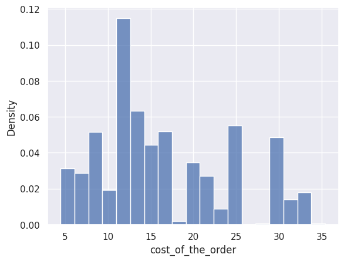

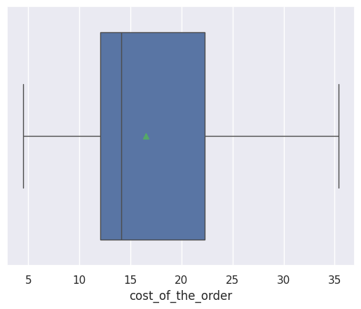

```python
a=sns.histplot(data=data,x='cost_of_the_order',stat='density')
plt.show()
print()
sns.boxplot(data=data,x='cost_of_the_order',showmeans=True)
plt.show()
```

- The distribution is slightly skewed towards right.
- There are no outliers.
- The median 14.14 dollars.

**Observations on food_preparation_time and delivery_time**

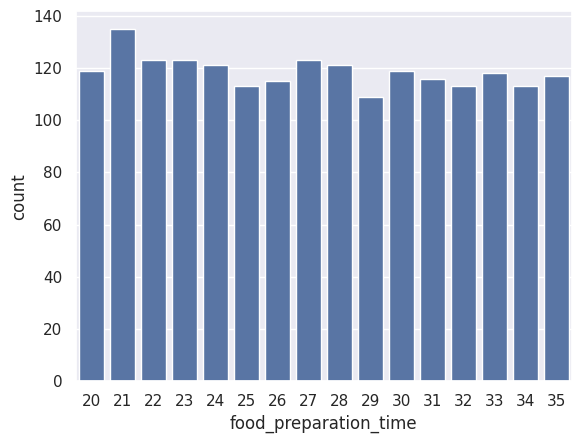

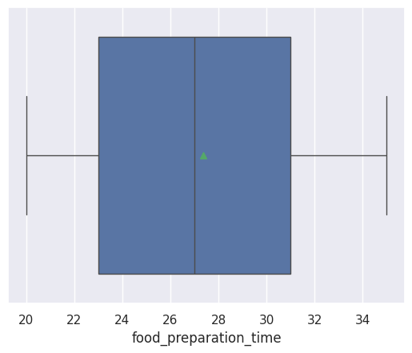

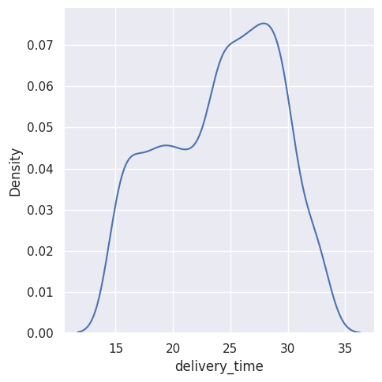

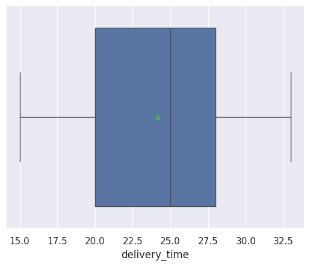

```python
sns.countplot(data=data,x='food_preparation_time')
plt.show()
print()
sns.boxplot(data=data,x='food_preparation_time',showmeans=True)
plt.show()
sns.displot(data=data,x='delivery_time',kind='kde')
print()
plt.show()
print()
sns.boxplot(data=data,x='delivery_time',showmeans=True)
plt.show()
```

**Observations on rating**

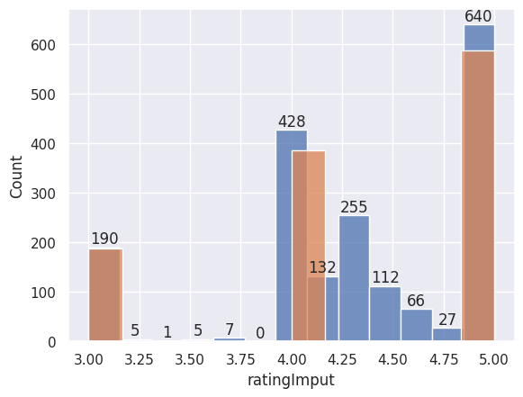

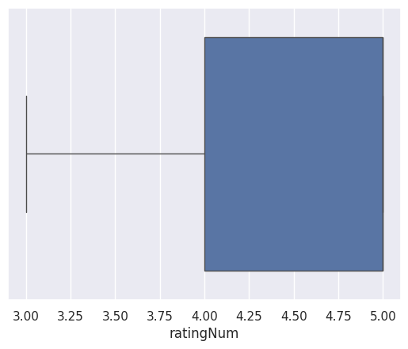

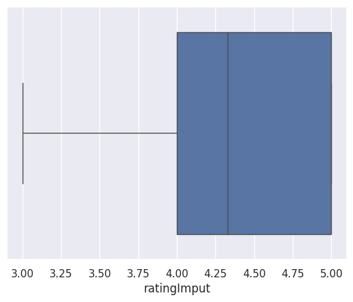

```python
x=sns.histplot(data=data,x='ratingImput')
y=sns.histplot(data=data,x='ratingNum')
x.bar_label(x.containers[0])
plt.show()
print()
a = sns.boxplot(data=data,x='ratingNum')
plt.show()
print()
b = sns.boxplot(data=data,x='ratingImput')
plt.show()
```

- The distribution is slightly skewed towards left.
- The imputed column shows a better picture of the averages.

**Observations on day_of_the_week**

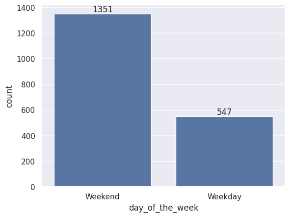

```python
a=sns.countplot(data=data, x='day_of_the_week')
a.bar_label(a.containers[0])
plt.show()
```

- Food orders increase over the weekend.

### **Question 7**: Which are the top 5 restaurants in terms of the number of orders received? [1 mark]

```python
# Check hoy many orders there are per restaurant
data['restaurant_name'].value_counts()
```

```
restaurant_name
Shake Shack                  219
The Meatball Shop            132
Blue Ribbon Sushi            119
Blue Ribbon Fried Chicken     96
Parm                          68
                            ...
Sushi Choshi                   1
Dos Caminos Soho               1
La Follia                      1
Philippe Chow                  1
'wichcraft                     1
Name: count, Length: 178, dtype: int64
```

#### Observations:

1. Shake Shack with 219 orders
2. The Meatball Shop with 132 orders
3. Blue Ribbon Sushi with 119 orders
4. Blue Ribbon Fried Chicken with 96 orders
5. Parm with 68 orders

### **Question 8**: Which is the most popular cuisine on weekends? [1 mark]

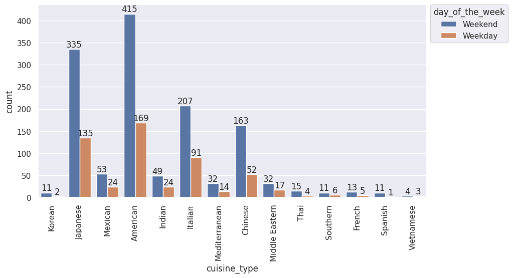

```python
plt.figure(figsize=(10,5))
a = sns.countplot(data=data, x='cuisine_type',hue='day_of_the_week')
plt.xticks(rotation=90)
for container in a.containers:
    a.bar_label(container)
sns.move_legend(a, bbox_to_anchor=(1, 1.02), loc='upper left')
plt.show()
```

#### Observations:

The most popular cuisine on weekends is American, with 415 orders.

### **Question 9**: What percentage of the orders cost more than 20 dollars? [2 marks]

```python
# Check the orders cost more than 20 dollars
print(data.loc[data['cost_of_the_order']>20].value_counts(), '\n')
# Calculate percentage of cost more than 20 dollars
x = data.loc[data['cost_of_the_order']>20].value_counts()
z=(x.shape[0]/data.shape[0]*100)
print('The percentage of the orders cost more than 20 dollars is: ', round(z,2),'%', sep='')
```

```
order_id  customer_id  restaurant_name            cuisine_type  cost_of_the_order  day_of_the_week  rating  ratingNum  ratingImput  food_preparation_time  delivery_time
1476560   149508       Shake Shack                American      22.26              Weekend          4       4.0        4.0          32                     17               1
1477847   106478       Blue Ribbon Sushi          Japanese      24.25              Weekday          4       4.0        4.0          22                     29               1
1477923   75115        RedFarm Hudson             Chinese       33.03              Weekend          3       3.0        3.0          32                     19               1
1477922   304587       Westville Hudson           American      33.03              Weekend          5       5.0        5.0          25                     18               1
1477921   97079        Benihana                   Japanese      29.29              Weekend          5       5.0        5.0          20                     18               1
                                                                                                                                                                           ..
1477221   125510       Blue Ribbon Sushi Izakaya  Japanese      33.03              Weekend          3       3.0        3.0          34                     23               1
1477220   41249        Kambi Ramen House          Japanese      32.93              Weekend          5       5.0        5.0          35                     19               1
1477219   389155       The Meatball Shop          Italian       32.98              Weekday          3       3.0        3.0          23                     25               1
1477218   333216       Shake Shack                American      29.49              Weekend          5       5.0        5.0          20                     24               1
1478444   355090       Shake Shack                American      31.43              Weekend          3       3.0        3.0          22                     24               1
Name: count, Length: 356, dtype: int64

The percentage of the orders cost more than 20 dollars is: 18.76%
```

### **Question 10**: What is the mean order delivery time? [1 mark]

```
The mean order delivery time is: 24.161749209694417
```

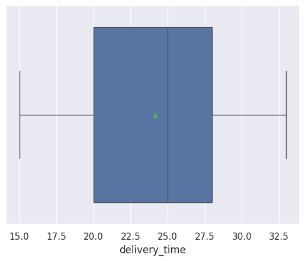

```python
print('The mean order delivery time is:', data['delivery_time'].describe().loc['mean'],'\n')
sns.boxplot(data=data, x='delivery_time', showmeans=True)
plt.show()
```

### **Question 11:** The company has decided to give 20% discount vouchers to the top 3 most frequent customers. Find the IDs of these customers and the number of orders they placed. [1 mark]

```python
print(data['customer_id'].value_counts().head(3))
```

```
customer_id
52832    13
47440    10
83287     9
Name: count, dtype: int64
```

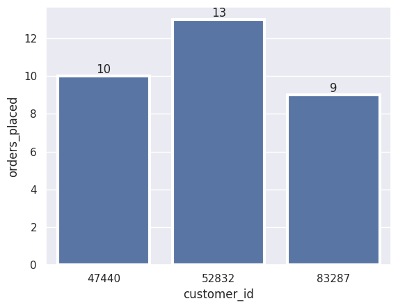

```python
#Create new dataframe with only the amount of orders per customer_id
top3Data = data['customer_id'].value_counts().rename_axis('customer_id').reset_index(name='orders_placed')
x=sns.barplot(x='customer_id', y='orders_placed',data=top3Data.nlargest(3,'orders_placed'),linewidth=3)
x.bar_label(x.containers[0])
plt.show()
```

#### Observations:

- The top 3 most frequent customers are:
1. 52832 with 13 orders
2. 47440 with 10 orders
3. 83287 with 9 orders

### **Question 12**: Perform a multivariate analysis to explore relationships between the important variables in the dataset. (It is a good idea to explore relations between numerical variables as well as relations between numerical and categorical variables) [10 marks]

```python
# create new column to get total preparation+delivery time
data['totalTime'] = data['food_preparation_time']+data['delivery_time']
```

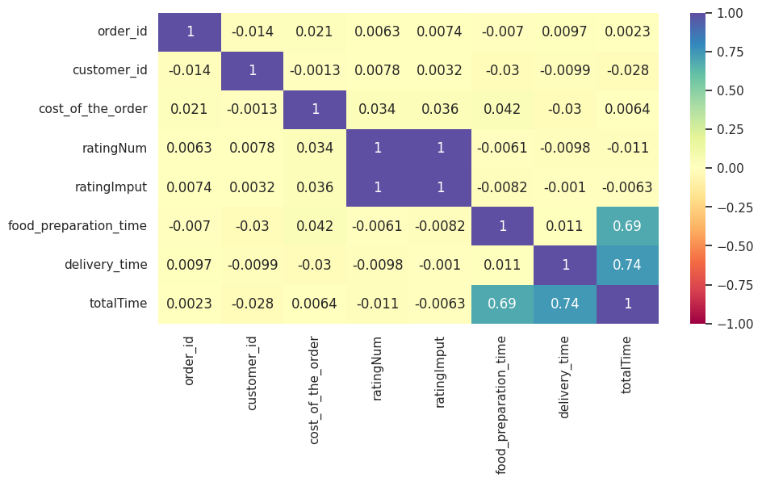

```python
plt.figure(figsize=(10,5))
sns.heatmap(data.corr(numeric_only=True), annot=True, cmap='Spectral',vmin=-1,vmax=1)
plt.show()
```

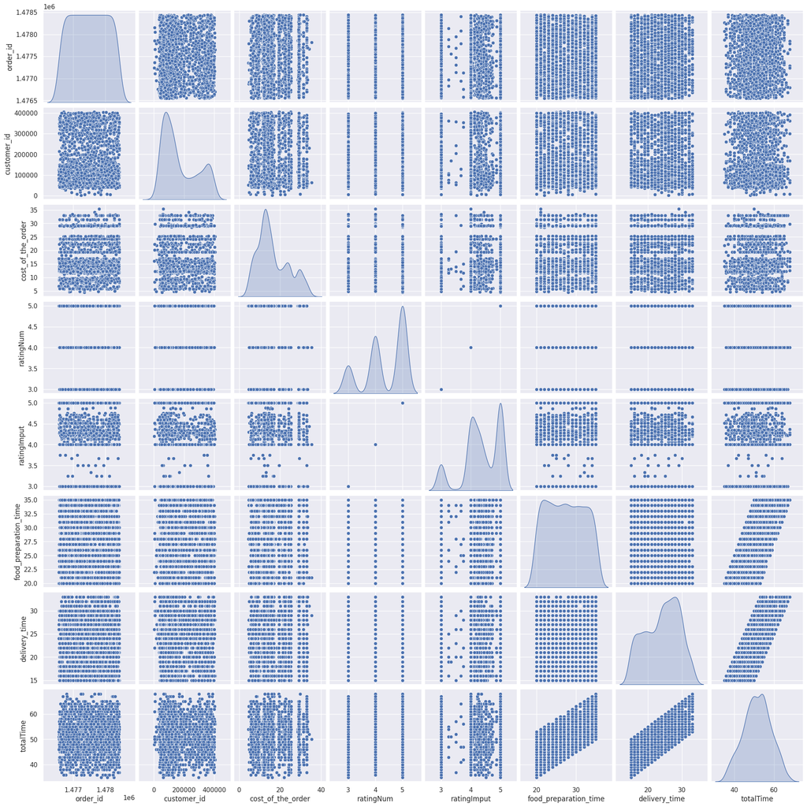

```python
sns.pairplot(data, diag_kind="kde");
```

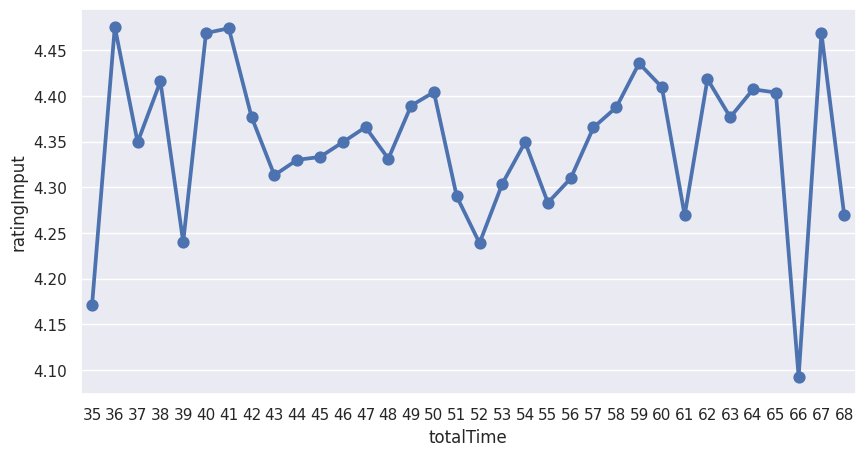

```python
plt.figure(figsize=(10,5))
sns.pointplot(data=data,x='totalTime',y='ratingImput', estimator='mean', errorbar=None)
plt.show()
```

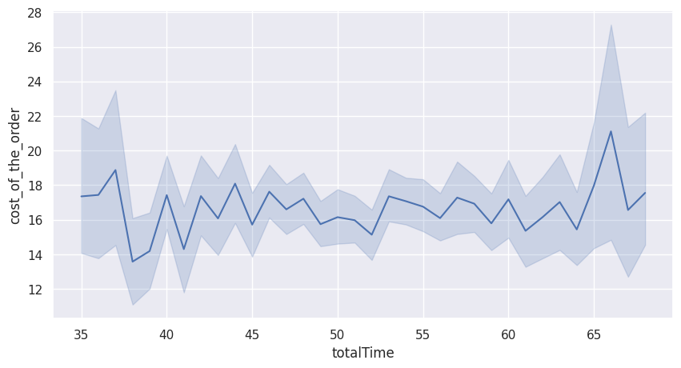

```python
plt.figure(figsize=(10,5))
sns.lineplot(data=data,x='totalTime',y='cost_of_the_order',estimator='mean', errorbar=('ci',95))
plt.show()
```

```python
data.groupby(['restaurant_name']).count().nlargest(10,'ratingNum')
```

| restaurant_name | order_id | customer_id | cuisine_type | cost_of_the_order | day_of_the_week | rating | ratingNum | ratingImput | food_preparation_time | delivery_time | totalTime |
| --- | --- | --- | --- | --- | --- | --- | --- | --- | --- | --- | --- |
| Shake Shack | 219 | 219 | 219 | 219 | 219 | 219 | 133 | 219 | 219 | 219 | 219 |
| The Meatball Shop | 132 | 132 | 132 | 132 | 132 | 132 | 84 | 132 | 132 | 132 | 132 |
| Blue Ribbon Sushi | 119 | 119 | 119 | 119 | 119 | 119 | 73 | 119 | 119 | 119 | 119 |
| Blue Ribbon Fried Chicken | 96 | 96 | 96 | 96 | 96 | 96 | 64 | 96 | 96 | 96 | 96 |
| RedFarm Broadway | 59 | 59 | 59 | 59 | 59 | 59 | 41 | 59 | 59 | 59 | 59 |
| Parm | 68 | 68 | 68 | 68 | 68 | 68 | 39 | 68 | 68 | 68 | 68 |
| RedFarm Hudson | 55 | 55 | 55 | 55 | 55 | 55 | 34 | 55 | 55 | 55 | 55 |
| TAO | 49 | 49 | 49 | 49 | 49 | 49 | 28 | 49 | 49 | 49 | 49 |
| Rubirosa | 37 | 37 | 37 | 37 | 37 | 37 | 24 | 37 | 37 | 37 | 37 |
| Han Dynasty | 46 | 46 | 46 | 46 | 46 | 46 | 23 | 46 | 46 | 46 | 46 |

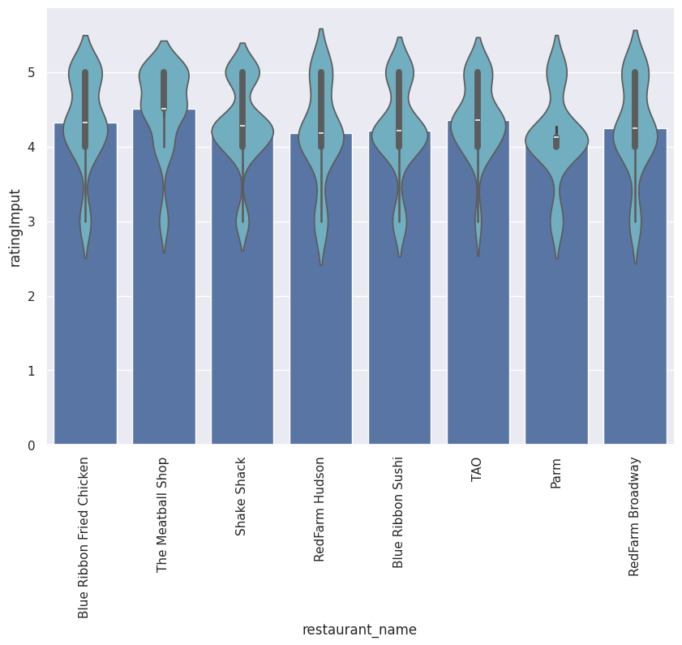

```python
#fitler restaurants with more than 46 orders
df2 = data.groupby('restaurant_name').filter(lambda x: len(x)>46)
plt.figure(figsize = (10,7)) # To resize the plot
sns.barplot(x="restaurant_name", y="ratingImput", data=df2)
sns.violinplot(x="restaurant_name", y="ratingImput", data=df2, color="c")
plt.xticks(rotation=90);
```

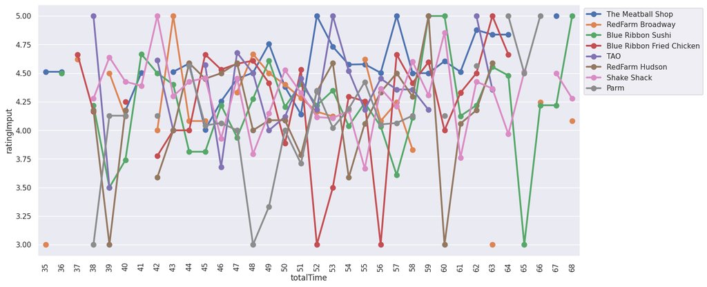

```python
plt.figure(figsize=(15, 7)) # To resize the plot
sns.pointplot(x='totalTime', y='ratingImput', data=df2, estimator='mean', errorbar=None, hue = 'restaurant_name')
plt.legend(bbox_to_anchor=(1, 1))
plt.xticks(rotation=90)
plt.show()
```

- All restaurants have good and bad reviews no matter the total time of order

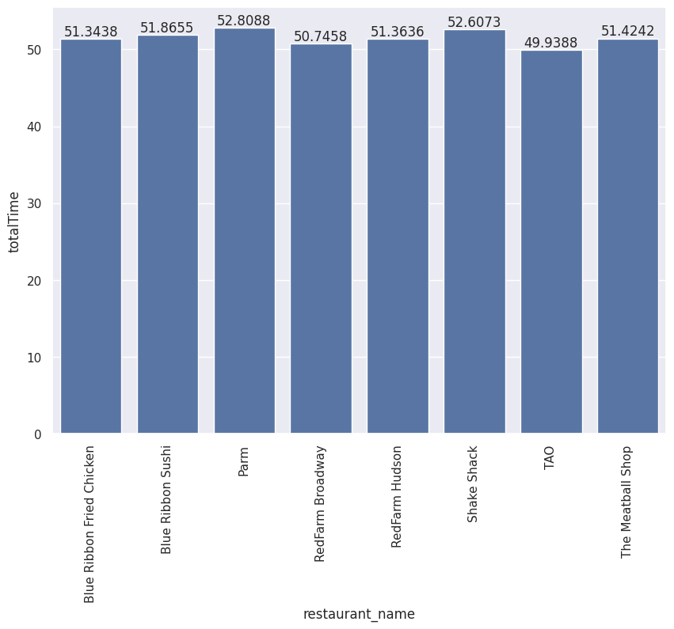

```python
df3=df2.groupby(['restaurant_name'])[['totalTime']].mean()
plt.figure(figsize = (10,7)) # To resize the plot
x=sns.barplot(x="restaurant_name", y="totalTime", data=df3)
x.bar_label(x.containers[0])
plt.xticks(rotation=90);
```

### **Question 13:** The company wants to provide a promotional offer in the advertisement of the restaurants. The condition to get the offer is that the restaurants must have a rating count of more than 50 and the average rating should be greater than 4. Find the restaurants fulfilling the criteria to get the promotional offer. [3 marks]

```python
#create new data frame with focused variables
dataPriceMean = data[['restaurant_name','cost_of_the_order','ratingNum','ratingImput','totalTime']].copy()
```

```python
#check the top 10 restaurantes with more count of ratings
dataPriceMean.groupby(['restaurant_name']).count().nlargest(10,'ratingNum')
```

| restaurant_name | cost_of_the_order | ratingNum | ratingImput | totalTime |
| --- | --- | --- | --- | --- |
| Shake Shack | 219 | 133 | 219 | 219 |
| The Meatball Shop | 132 | 84 | 132 | 132 |
| Blue Ribbon Sushi | 119 | 73 | 119 | 119 |
| Blue Ribbon Fried Chicken | 96 | 64 | 96 | 96 |
| RedFarm Broadway | 59 | 41 | 59 | 59 |
| Parm | 68 | 39 | 68 | 68 |
| RedFarm Hudson | 55 | 34 | 55 | 55 |
| TAO | 49 | 28 | 49 | 49 |
| Rubirosa | 37 | 24 | 37 | 37 |
| Han Dynasty | 46 | 23 | 46 | 46 |

```python
#new df with only entries where the rating is>4
dataRatingOver4 = dataPriceMean[dataPriceMean['ratingNum']>4].groupby('restaurant_name')['ratingNum'].count().rename_axis('restaurant_name').reset_index(name='counts').copy()
#check the top 10 restaurantes with more count of ratings
dataRatingOver4.nlargest(10,'counts')
```

|  | restaurant_name | counts |
| --- | --- | --- |
| 91 | Shake Shack | 60 |
| 103 | The Meatball Shop | 53 |
| 14 | Blue Ribbon Fried Chicken | 32 |
| 15 | Blue Ribbon Sushi | 32 |
| 81 | RedFarm Broadway | 18 |
| 16 | Blue Ribbon Sushi Bar & Grill | 15 |
| 82 | RedFarm Hudson | 15 |
| 75 | Parm | 14 |
| 46 | Han Dynasty | 13 |
| 98 | TAO | 13 |

```python
#new df with only entries where the rating count is > 50
dataRatingOver50 = dataRatingOver4[dataRatingOver4['counts']>50]
dataRatingOver50
```

|  | restaurant_name | counts |
| --- | --- | --- |
| 91 | Shake Shack | 60 |
| 103 | The Meatball Shop | 53 |

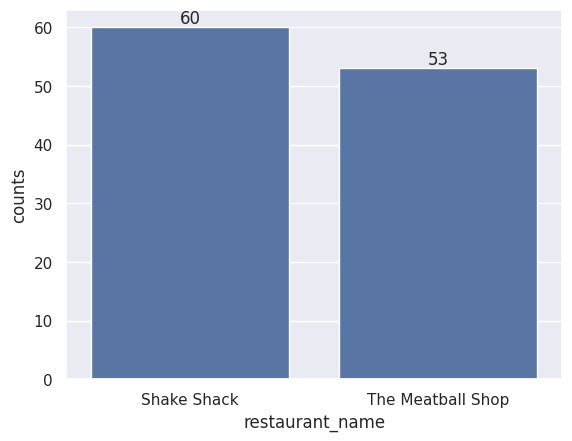

```python
a = sns.barplot(data=dataRatingOver50, x='restaurant_name', y='counts')
a.bar_label(a.containers[0])
plt.show()
```

#### Observations:

```python
# Create a new df with only the restaurant name and cost of each order
dataRevenue = data[['restaurant_name','cost_of_the_order']].copy()
dataRevenue.head()
```

|  | restaurant_name | cost_of_the_order |
| --- | --- | --- |
| 0 | Hangawi | 30.75 |
| 1 | Blue Ribbon Sushi Izakaya | 12.08 |
| 2 | Cafe Habana | 12.23 |
| 3 | Blue Ribbon Fried Chicken | 29.20 |
| 4 | Dirty Bird to Go | 11.59 |

```python
#check cost_of_the_order > 20
dataRevenue.loc[(dataRevenue['cost_of_the_order'] > 20.0)]
```

|  | restaurant_name | cost_of_the_order |
| --- | --- | --- |
| 0 | Hangawi | 30.75 |
| 3 | Blue Ribbon Fried Chicken | 29.20 |
| 5 | Tamarind TriBeCa | 25.22 |
| 12 | Blue Ribbon Fried Chicken | 24.30 |
| 17 | Blue Ribbon Sushi Izakaya | 33.03 |
| ... | ... | ... |
| 1884 | Shake Shack | 31.43 |
| 1885 | Shake Shack | 29.05 |
| 1892 | Han Dynasty | 29.15 |
| 1893 | Chipotle Mexican Grill $1.99 Delivery | 22.31 |
| 1895 | Blue Ribbon Sushi | 25.22 |

555 rows × 2 columns

```python
#create contidiont to clasify each order depending the cost.
'''
tier1 = 'cost_of_the_order' <= 5.0
tier2 = ''cost_of_the_order' > 5.0 & 'cost_of_the_order' <= 20.0
tier3 = 'cost_of_the_order'] > 20.0
'''
conditions = [
    (dataRevenue['cost_of_the_order'] <= 5.0),
    (dataRevenue['cost_of_the_order'] > 5.0) & (dataRevenue['cost_of_the_order'] <= 20.0),
    (dataRevenue['cost_of_the_order'] > 20.0)
    ]

revClass = ['tier1', 'tier2','tier3']
#create new column for each revenue class
dataRevenue['revClass'] = np.select(conditions, revClass)
```

```python
dataRevenue.head()
```

|  | restaurant_name | cost_of_the_order | revClass |
| --- | --- | --- | --- |
| 0 | Hangawi | 30.75 | tier3 |
| 1 | Blue Ribbon Sushi Izakaya | 12.08 | tier2 |
| 2 | Cafe Habana | 12.23 | tier2 |
| 3 | Blue Ribbon Fried Chicken | 29.20 | tier3 |
| 4 | Dirty Bird to Go | 11.59 | tier2 |

```python
dataRevenue.loc[(dataRevenue['cost_of_the_order'] <= 5)]
```

|  | restaurant_name | cost_of_the_order | revClass |
| --- | --- | --- | --- |
| 82 | Shake Shack | 4.75 | tier1 |
| 390 | Cafe Habana | 4.85 | tier1 |
| 480 | The Loop | 4.66 | tier1 |
| 542 | P.J. Clarke's | 4.71 | tier1 |
| 624 | Nobu Next Door | 4.47 | tier1 |
| 664 | Blue Ribbon Sushi Bar & Grill | 4.85 | tier1 |
| 889 | Shake Shack | 4.80 | tier1 |
| 1569 | RedFarm Hudson | 4.75 | tier1 |
| 1695 | Blue Ribbon Sushi Bar & Grill | 4.90 | tier1 |

```python
#create new df with the total value of sales for each revenue class
dataChargesOverSales = dataRevenue.groupby(['revClass'])['cost_of_the_order'].sum().rename_axis('revClass').reset_index(name='totalSales')
#create new column with the calculation of the total revenue pver the total sales value
dataChargesOverSales.loc[dataChargesOverSales['revClass'] == 'tier1', 'revenue'] = np.round(dataChargesOverSales['totalSales']*0,2)
dataChargesOverSales.loc[dataChargesOverSales['revClass'] == 'tier2', 'revenue'] = np.round(dataChargesOverSales['totalSales']*0.15,2)
dataChargesOverSales.loc[dataChargesOverSales['revClass'] == 'tier3', 'revenue'] = np.round(dataChargesOverSales['totalSales']*0.20,2)

#create new column with the calculation of the total revenue pver the total sales value
dataChargesOverSales['totalSum'] = dataChargesOverSales['totalSales'] + dataChargesOverSales['revenue']
dataChargesOverSales
```

|  | revClass | totalSales | revenue | totalSum |
| --- | --- | --- | --- | --- |
| 0 | tier1 | 42.74 | 0.00 | 42.74 |
| 1 | tier2 | 16517.17 | 2477.58 | 18994.75 |
| 2 | tier3 | 14754.91 | 2950.98 | 17705.89 |

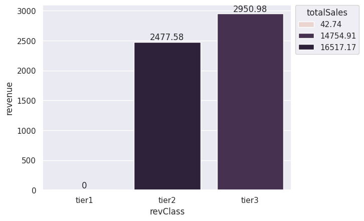

```python
a = sns.barplot(data=dataChargesOverSales, x='revClass', y='revenue', hue='totalSales')
for container in a.containers:
    a.bar_label(container)
sns.move_legend(a, bbox_to_anchor=(1, 1.02), loc='upper left')
plt.show()
```

```python
#sum the revenues fo each tier
np.round(dataChargesOverSales['revenue'].sum(),2)
```

```
5428.56
```

### **Question 15:** The company wants to analyze the total time required to deliver the food. What percentage of orders take more than 60 minutes to get delivered from the time the order is placed? (The food has to be prepared and then delivered.) [2 marks]

```python
#create a colum which sum totalTime
data['totalTime'].describe()
```

```
count    1898.000000
mean       51.533720
std         6.833603
min        35.000000
25%        47.000000
50%        52.000000
75%        56.000000
max        68.000000
Name: totalTime, dtype: float64
```

```python
#check order that last more than 60 minutes
data.loc[data['totalTime']>60].value_counts()
```

```
order_id  customer_id  restaurant_name                cuisine_type  cost_of_the_order  day_of_the_week  rating  ratingNum  ratingImput  food_preparation_time  delivery_time  totalTime
1476565   41991        Blue Ribbon Sushi Bar & Grill  Japanese      15.33              Weekend          5       5.0        5.0          32                     29             61           1
1477826   381020       RedFarm Broadway               Chinese       8.20               Weekend          4       4.0        4.0          31                     30             61           1
1477917   71249        Momoya                         Japanese      24.30              Weekend          4       4.0        4.0          35                     30             65           1
1477912   261400       The Meatball Shop              Italian       19.45              Weekday          5       5.0        5.0          31                     32             63           1
1477900   276192       Sushi of Gari Tribeca          Japanese      8.63               Weekend          5       5.0        5.0          33                     28             61           1
                                                                                                                                                                                          ..
1477229   72339        Hatsuhana                      Japanese      17.03              Weekday          4       4.0        4.0          35                     33             68           1
1477193   304291       P.J. Clarke's                  American      5.92               Weekday          3       3.0        3.0          33                     30             63           1
1477154   143796       S'MAC                          American      5.92               Weekday          4       4.0        4.0          34                     30             64           1
1477145   207281       Shake Shack                    American      29.30              Weekday          5       5.0        5.0          33                     32             65           1
1478424   304052       Parm                           Italian       11.59              Weekday          5       5.0        5.0          35                     29             64           1
Name: count, Length: 119, dtype: int64
```

```python
#calculate % of orders that last more than 60 minutes
x = data.loc[data['totalTime']>60].value_counts()
z=(x.shape[0]/data.shape[0]*100)
print('The percentage of orders that take more than 60 minutes to get delivered from the time the order is placed is: ', round(z,2),'%', '\n', sep='')
```

```
The percentage of orders that take more than 60 minutes to get delivered from the time the order is placed is: 6.27%
```

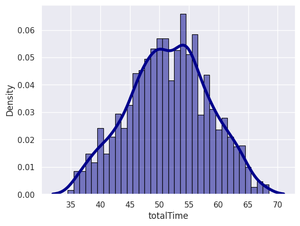

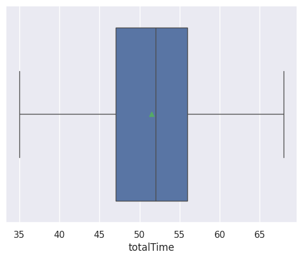

```python
a = sns.histplot(data=data,x='totalTime',stat='density',discrete=True,color='darkblue', edgecolor='black',kde=True, kde_kws={'cut': 2}, line_kws={'linewidth': 4})
plt.show()
print()
b = sns.boxplot(data=data, x='totalTime',showmeans=True)
plt.show()
```

### **Question 16:** The company wants to analyze the delivery time of the orders on weekdays and weekends. How does the mean delivery time vary during weekdays and weekends? [2 marks]

```python
dataDays = data.groupby('day_of_the_week')['totalTime']
dataDays.describe()
```

| day_of_the_week | count | mean | std | min | 25% | 50% | 75% | max |
| --- | --- | --- | --- | --- | --- | --- | --- | --- |
| Weekday | 547.0 | 55.552102 | 5.567972 | 44.0 | 51.0 | 55.0 | 59.5 | 68.0 |
| Weekend | 1351.0 | 49.906736 | 6.624883 | 35.0 | 45.0 | 50.0 | 55.0 | 65.0 |

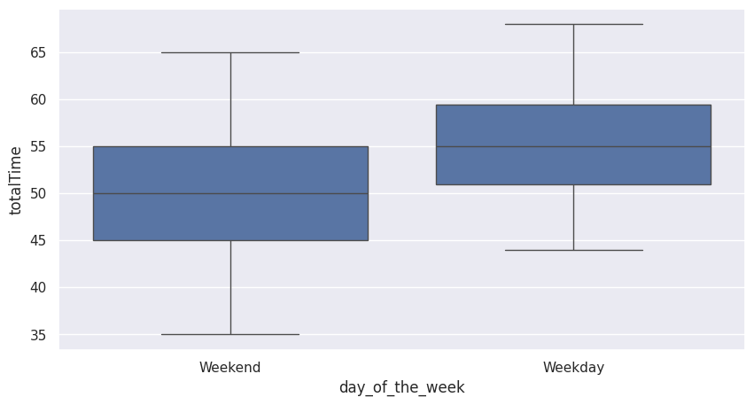

```python
plt.figure(figsize=(10,5))
sns.boxplot(data=data,x='day_of_the_week',y='totalTime',showfliers=True) # turning off outliers
plt.show()
```

### Recommendations:

- *Take rating as floating point values, so the averagings will be better represented and the plots will have more resolution points.*
- *Use all days' names as strings, Monday to Friday, and Saturday and Sunday, and not only two 'weekday' and 'weekend'.*
- *Consider tracking the time of the day the was placed and the hour the order was delivered at the customer location.*